# Assignment MLR

2023-12-09

# **Group Member**

1 Ijlal Syamim bin Mohd Basri

2 Muhammad Naim bin Deraman

3 Mohd Aslam bin Ariffin

4 ’Abdul Muntaqim bin Abu Bakar

5 Mohd Fahmin bin Kmarul Zaman

# **Dataset**

We will use medical personal cost dataset obtained from kaggle.com. This dataset contain medical information and costs billed by health insurance companies. It contains 1338 rows of data and the following columns: age, gender, BMI, children, smoker, region and insurance charges. 1 ID 2 age: age of primary beneficiary 3 sex: insurance contractor gender, female, male 4 bmi: Body mass index, providing an understanding of body, weights that are relatively high or low relative to height, objective index of body weight (kg / m ^ 2) using the ratio of height to weight, ideally 18.5 to 24.9 5 children: Number of children covered by health insurance / Number of dependents 6 smoker: Smoking 7 region: the beneficiary’s residential area in the US, northeast, southeast, southwest, northwest. 8 charges: Individual medical costs billed by health insurance

## **Method**

We will employ the Linear Regression Analysis from the dataset.

We want to predict the relationship between the insurance charges and its associated factors (independent variables) as below age: in year (numerical) sex: male and female (categorical) bmi: body mass index (numerical) children: number of dependant (numerical) smoker: smoking status (categorical) region: individual’s residence (categorical)

# **Load R packages**

```r
library(tidyverse)
library(haven)
library(here)
library(gtsummary)
```

```r
library(corrplot)
library(knitr)
library(broom)
library(tidyr)
library(dplyr)
```

# **Read data**

```r
ourdata1 <- read_csv(here('raw_data', 'insurance.csv'))
```

# **Describe data**

```r
summary(ourdata1)
```

```
##       age            sex                 bmi           children
##  Min.   :18.00   Length:1338        Min.   :15.96   Min.   :0.000
##  1st Qu.:27.00   Class :character   1st Qu.:26.30   1st Qu.:0.000
##  Median :39.00   Mode  :character   Median :30.40   Median :1.000
##  Mean   :39.21                      Mean   :30.66   Mean   :1.095
##  3rd Qu.:51.00                      3rd Qu.:34.69   3rd Qu.:2.000
##  Max.   :64.00                      Max.   :53.13   Max.   :5.000
##     smoker             region             charges
##  Length:1338        Length:1338        Min.   : 1122
##  Class :character   Class :character   1st Qu.: 4740
##  Mode  :character   Mode  :character   Median : 9382
##                                        Mean   :13270
##                                        3rd Qu.:16640
##                                        Max.   :63770
```

# **Another way to look at data**

```r
str(ourdata1)
```

```
## spc_tbl_ [1,338 × 7] (S3: spec_tbl_df/tbl_df/tbl/data.frame)
##  $ age     : num [1:1338] 19 18 28 33 32 31 46 37 37 60 ...
##  $ sex     : chr [1:1338] "female" "male" "male" "male" ...
##  $ bmi     : num [1:1338] 27.9 33.8 33 22.7 28.9 ...
##  $ children: num [1:1338] 0 1 3 0 0 0 1 3 2 0 ...
##  $ smoker  : chr [1:1338] "yes" "no" "no" "no" ...
##  $ region  : chr [1:1338] "southwest" "southeast" "southeast" "northwest" ...
##  $ charges : num [1:1338] 16885 1726 4449 21984 3867 ...
##  - attr(*, "spec")=
##   .. cols(
##   ..   age = col_double(),
##   ..   sex = col_character(),
##   ..   bmi = col_double(),
##   ..   children = col_double(),
##   ..   smoker = col_character(),
##   ..   region = col_character(),
##   ..   charges = col_double()
##   .. )
##  - attr(*, "problems")=<externalptr>
```

# **Add numbering to first column because original datset has none of it**

```r
ourdata1$ID <- seq_len(nrow(ourdata1))
ourdata1 <- ourdata1[, c("ID", names(ourdata1)[-which(names(ourdata1) == "ID")])]
```

# **re look at our data**

```r
summary(ourdata1)
```

```
##        ID              age            sex                 bmi
##  Min.   :   1.0   Min.   :18.00   Length:1338        Min.   :15.96
##  1st Qu.: 335.2   1st Qu.:27.00   Class :character   1st Qu.:26.30
##  Median : 669.5   Median :39.00   Mode  :character   Median :30.40
##  Mean   : 669.5   Mean   :39.21                      Mean   :30.66
##  3rd Qu.:1003.8   3rd Qu.:51.00                      3rd Qu.:34.69
##  Max.   :1338.0   Max.   :64.00                      Max.   :53.13
##     children        smoker             region             charges
##  Min.   :0.000   Length:1338        Length:1338        Min.   : 1122
##  1st Qu.:0.000   Class :character   Class :character   1st Qu.: 4740
##  Median :1.000   Mode  :character   Mode  :character   Median : 9382
##  Mean   :1.095                                         Mean   :13270
##  3rd Qu.:2.000                                         3rd Qu.:16640
##  Max.   :5.000                                         Max.   :63770
```

# **Convert labelled variables to factor variables**

```r
ourdata1$sex <- as.factor(ourdata1$sex)
ourdata1$region <- as.factor(ourdata1$region)
ourdata1$smoker <- as.factor(ourdata1$smoker)
summary(ourdata1)
```

```
##        ID              age            sex           bmi           children
##  Min.   :   1.0   Min.   :18.00   female:662   Min.   :15.96   Min.   :0.000
##  1st Qu.: 335.2   1st Qu.:27.00   male  :676   1st Qu.:26.30   1st Qu.:0.000
##  Median : 669.5   Median :39.00                Median :30.40   Median :1.000
##  Mean   : 669.5   Mean   :39.21                Mean   :30.66   Mean   :1.095
##  3rd Qu.:1003.8   3rd Qu.:51.00                3rd Qu.:34.69   3rd Qu.:2.000
##  Max.   :1338.0   Max.   :64.00                Max.   :53.13   Max.   :5.000
##  smoker           region       charges
##  no :1064   northeast:324   Min.   : 1122
##  yes: 274   northwest:325   1st Qu.: 4740
##             southeast:364   Median : 9382
##             southwest:325   Mean   :13270
##                             3rd Qu.:16640
##                             Max.   :63770
```

# **use gtsummary to get desired descriptive analysis**

```r
ourdata1 %>%
  select(-ID) %>%
  tbl_summary(
    statistic = list(all_continuous() ~ "{mean} ({sd})")
  )
```

| **Characteristic** | **N = 1,338**<sup>1</sup> |
| --- | --- |
| age | 39 (14) |
| sex |  |
| female | 662 (49%) |
| male | 676 (51%) |
| bmi | 30.7 (6.1) |
| children |  |
| 0 | 574 (43%) |
| 1 | 324 (24%) |
| 2 | 240 (18%) |
| 3 | 157 (12%) |
| 4 | 25 (1.9%) |
| 5 | 18 (1.3%) |
| smoker | 274 (20%) |
| region |  |
| northeast | 324 (24%) |
| northwest | 325 (24%) |
| southeast | 364 (27%) |
| southwest | 325 (24%) |
| charges | 13,270 (12,110) |

<sup>1</sup> Mean (SD); n (%)

# **Explore and wrangle data - perform plots**

Performs plots, to look for

1 outlier

2 range of data

3 missing data

4 error in data entry

5 wrong groupings

6 distribution of data

Charges

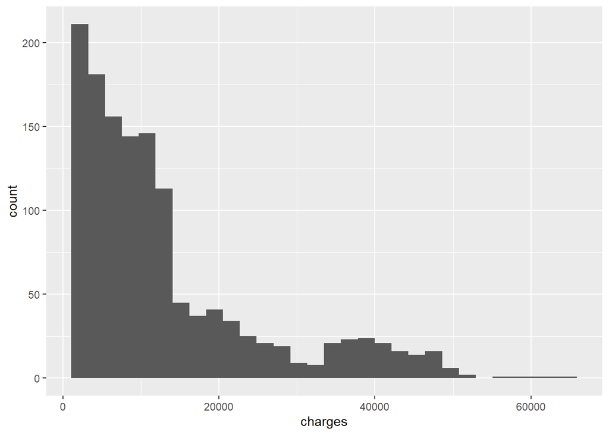

```r
ggplot(ourdata1, aes(charges)) +
  geom_histogram()
```

Age

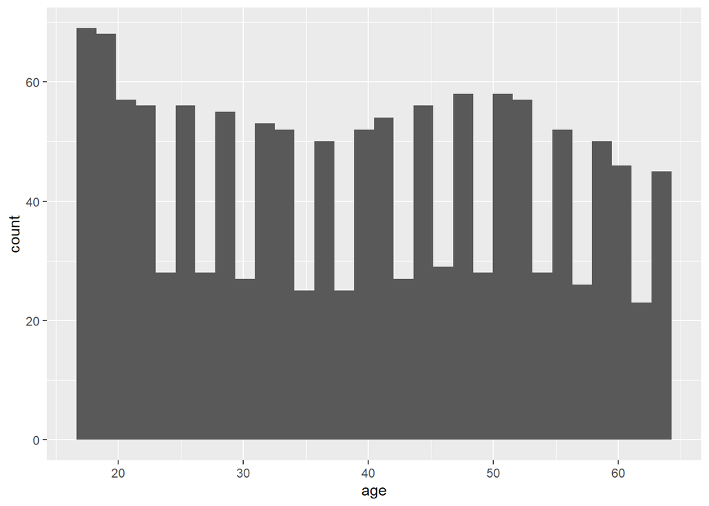

```r
ggplot(ourdata1, aes(age)) +
  geom_histogram()
```

BMI

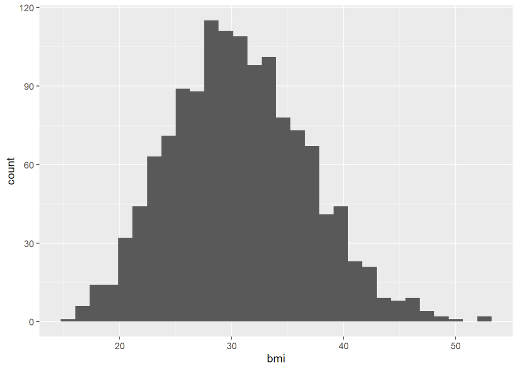

```r
ggplot(ourdata1, aes(bmi)) +
  geom_histogram()
```

Number of Dependant

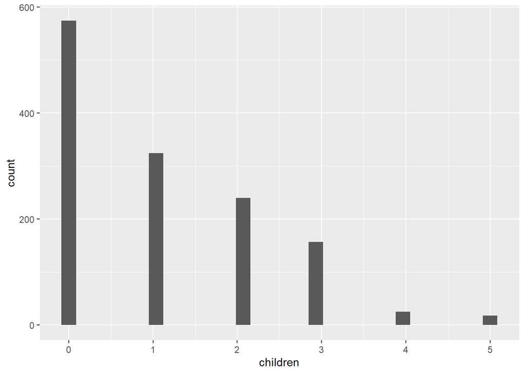

```r
ggplot(ourdata1, aes(children)) +
  geom_histogram()
```

Sex

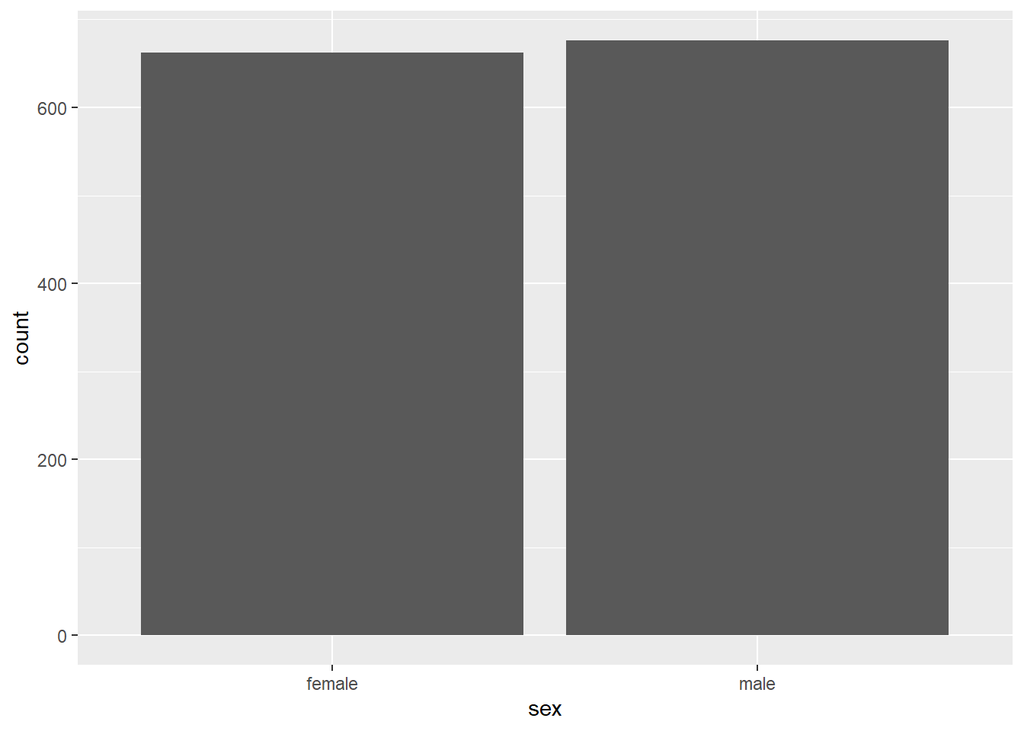

```r
ggplot(ourdata1, aes(x = sex)) +
  geom_bar()
```

Smoking Status

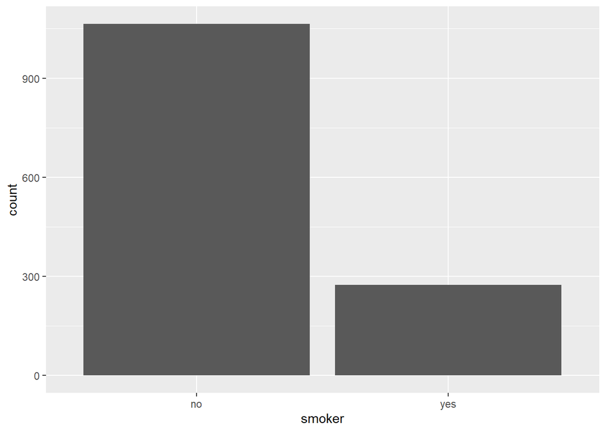

```r
ggplot(ourdata1, aes(x = smoker)) +
  geom_bar()
```

Region

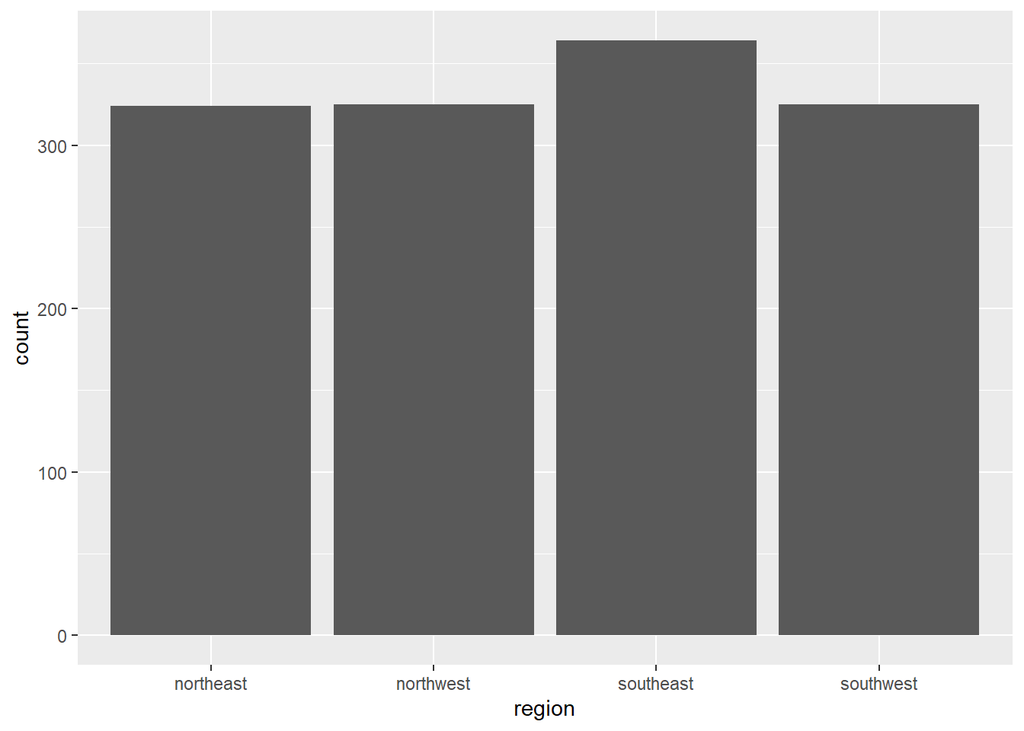

```r
ggplot(ourdata1, aes(x = region)) +
  geom_bar()
```

# **check correlation between numerical variables**

```r
ourdata3 <-
  ourdata1 %>%
  select(where(is.numeric))
```

```r
cor.ourdata1 <-
  cor(ourdata3,
      use = "complete.obs",
      method = "pearson")
head(round(cor.ourdata1, 2))
```

```
##             ID   age   bmi children charges
## ID        1.00 -0.03 -0.04     0.03    0.00
## age      -0.03  1.00  0.11     0.04    0.30
## bmi      -0.04  0.11  1.00     0.01    0.20
## children  0.03  0.04  0.01     1.00    0.07
## charges   0.00  0.30  0.20     0.07    1.00
```

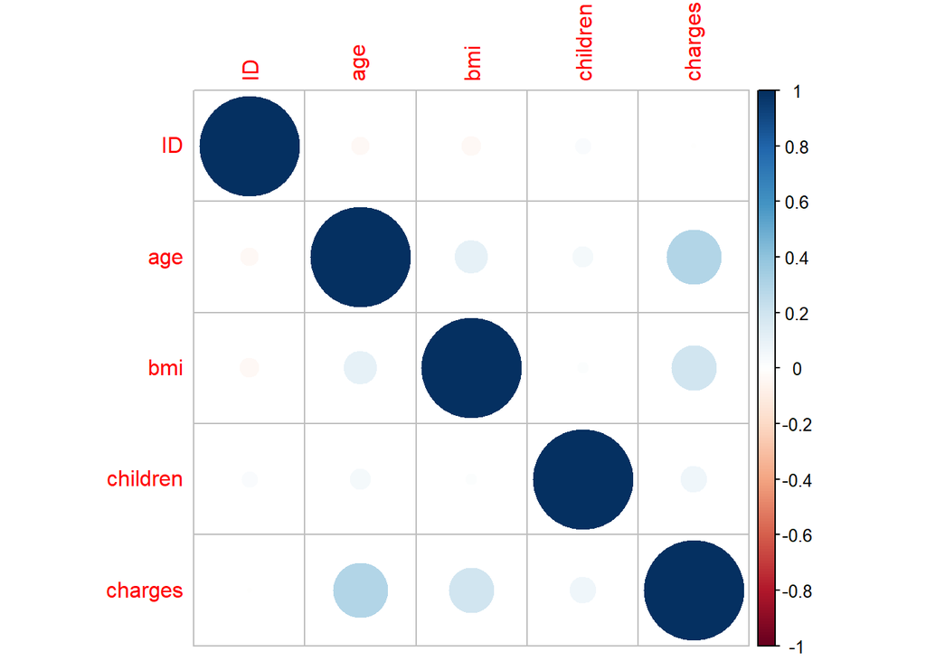

```r
corrplot(cor.ourdata1,
         method = "circle")
```

there is no correlation issue between numerical variables

# **perform univariate analysis**

outcome: insurance charges independant variables: age, sex, children, bmi, smoker, region Age

```r
mod.age <- lm(charges ~ age, data = ourdata1)
summary(mod.age)
```

```
##
## Call:
## lm(formula = charges ~ age, data = ourdata1)
##
## Residuals:
##    Min     1Q Median     3Q    Max
##  -8059  -6671  -5939   5440  47829
##
## Coefficients:
##             Estimate Std. Error t value Pr(>|t|)
## (Intercept)   3165.9      937.1   3.378 0.000751 ***
## age            257.7       22.5  11.453  < 2e-16 ***
## ---
## Signif. codes:  0 '***' 0.001 '**' 0.01 '*' 0.05 '.' 0.1 ' ' 1
##
## Residual standard error: 11560 on 1336 degrees of freedom
## Multiple R-squared:  0.08941,    Adjusted R-squared:  0.08872
## F-statistic: 131.2 on 1 and 1336 DF,  p-value: < 2.2e-16
```

```r
tidy(mod.age, conf.int = TRUE)
```

```
## # A tibble: 2 × 7
##   term        estimate std.error statistic  p.value conf.low conf.high
##   <chr>          <dbl>     <dbl>     <dbl>    <dbl>    <dbl>     <dbl>
## 1 (Intercept)    3166.     937.       3.38 7.51e- 4    1327.     5004.
## 2 age             258.      22.5     11.5  4.89e-29     214.      302.
```

Smoker

```r
mod.smoker <- lm(charges ~ smoker, data = ourdata1)
summary(mod.smoker)
```

```
##
## Call:
## lm(formula = charges ~ smoker, data = ourdata1)
##
## Residuals:
##    Min     1Q Median     3Q    Max
## -19221  -5042   -919   3705  31720
##
## Coefficients:
##             Estimate Std. Error t value Pr(>|t|)
## (Intercept)   8434.3      229.0   36.83   <2e-16 ***
## smokeryes    23616.0      506.1   46.66   <2e-16 ***
## ---
## Signif. codes:  0 '***' 0.001 '**' 0.01 '*' 0.05 '.' 0.1 ' ' 1
##
## Residual standard error: 7470 on 1336 degrees of freedom
## Multiple R-squared:  0.6198, Adjusted R-squared:  0.6195
## F-statistic:  2178 on 1 and 1336 DF,  p-value: < 2.2e-16
```

```r
tidy(mod.smoker, conf.int = TRUE)
```

```
## # A tibble: 2 × 7
##   term        estimate std.error statistic   p.value conf.low conf.high
##   <chr>          <dbl>     <dbl>     <dbl>     <dbl>    <dbl>     <dbl>
## 1 (Intercept)    8434.      229.      36.8 1.58e-205    7985.     8884.
## 2 smokeryes     23616.      506.      46.7 8.27e-283   22623.    24609.
```

Region

```r
mod.region <- lm(charges ~ region, data = ourdata1)
summary(mod.region)
```

```
##
## Call:
## lm(formula = charges ~ region, data = ourdata1)
##
## Residuals:
##    Min     1Q Median     3Q    Max
## -13614  -8463  -3793   3385  49035
##
## Coefficients:
##                 Estimate Std. Error t value Pr(>|t|)
## (Intercept)      13406.4      671.3  19.971   <2e-16 ***
## regionnorthwest   -988.8      948.6  -1.042    0.297
## regionsoutheast   1329.0      922.9   1.440    0.150
## regionsouthwest  -1059.4      948.6  -1.117    0.264
## ---
## Signif. codes:  0 '***' 0.001 '**' 0.01 '*' 0.05 '.' 0.1 ' ' 1
##
## Residual standard error: 12080 on 1334 degrees of freedom
## Multiple R-squared:  0.006634,   Adjusted R-squared:  0.0044
## F-statistic:  2.97 on 3 and 1334 DF,  p-value: 0.03089
```

```r
tidy(mod.region, conf.int = TRUE)
```

```
## # A tibble: 4 × 7
##   term            estimate std.error statistic  p.value conf.low conf.high
##   <chr>              <dbl>     <dbl>     <dbl>    <dbl>    <dbl>     <dbl>
## 1 (Intercept)       13406.      671.     20.0  7.67e-78   12089.    14723.
## 2 regionnorthwest    -989.      949.     -1.04 2.97e- 1   -2850.      872.
## 3 regionsoutheast    1329.      923.      1.44 1.50e- 1    -481.     3140.
## 4 regionsouthwest   -1059.      949.     -1.12 2.64e- 1   -2920.      802.
```

BMI

```r
mod.bmi <- lm(charges ~ bmi, data = ourdata1)
summary(mod.bmi)
```

```
##
## Call:
## lm(formula = charges ~ bmi, data = ourdata1)
##
## Residuals:
##    Min     1Q Median     3Q    Max
## -20956  -8118  -3757   4722  49442
##
## Coefficients:
##             Estimate Std. Error t value Pr(>|t|)
## (Intercept)  1192.94    1664.80   0.717    0.474
## bmi           393.87      53.25   7.397 2.46e-13 ***
## ---
## Signif. codes:  0 '***' 0.001 '**' 0.01 '*' 0.05 '.' 0.1 ' ' 1
##
## Residual standard error: 11870 on 1336 degrees of freedom
## Multiple R-squared:  0.03934,    Adjusted R-squared:  0.03862
## F-statistic: 54.71 on 1 and 1336 DF,  p-value: 2.459e-13
```

```r
tidy(mod.bmi, conf.int = TRUE)
```

```
## # A tibble: 2 × 7
##   term        estimate std.error statistic  p.value conf.low conf.high
##   <chr>          <dbl>     <dbl>     <dbl>    <dbl>    <dbl>     <dbl>
## 1 (Intercept)    1193.    1665.      0.717 4.74e- 1   -2073.     4459.
## 2 bmi             394.      53.3     7.40  2.46e-13     289.      498.
```

Sex

```r
mod.sex <- lm(charges ~ sex, data = ourdata1)
summary(mod.sex)
```

```
##
## Call:
## lm(formula = charges ~ sex, data = ourdata1)
##
## Residuals:
##    Min     1Q Median     3Q    Max
## -12835  -8435  -3980   3476  51201
##
## Coefficients:
##             Estimate Std. Error t value Pr(>|t|)
## (Intercept)  12569.6      470.1  26.740   <2e-16 ***
## sexmale       1387.2      661.3   2.098   0.0361 *
## ---
## Signif. codes:  0 '***' 0.001 '**' 0.01 '*' 0.05 '.' 0.1 ' ' 1
##
## Residual standard error: 12090 on 1336 degrees of freedom
## Multiple R-squared:  0.003282,   Adjusted R-squared:  0.002536
## F-statistic:   4.4 on 1 and 1336 DF,  p-value: 0.03613
```

```r
tidy(mod.sex, conf.int = TRUE)
```

```
## # A tibble: 2 × 7
##   term        estimate std.error statistic   p.value conf.low conf.high
##   <chr>          <dbl>     <dbl>     <dbl>     <dbl>    <dbl>     <dbl>
## 1 (Intercept)   12570.      470.     26.7  1.63e-126  11647.     13492.
## 2 sexmale        1387.      661.      2.10 3.61e-  2     89.8     2685.
```

Children

```r
mod.children <- lm(charges ~ children, data = ourdata1)
summary(mod.children)
```

```
##
## Call:
## lm(formula = charges ~ children, data = ourdata1)
##
## Residuals:
##    Min     1Q Median     3Q    Max
## -11585  -8759  -4071   3468  51248
##
## Coefficients:
##             Estimate Std. Error t value Pr(>|t|)
## (Intercept)  12522.5      446.5  28.049   <2e-16 ***
## children       683.1      274.2   2.491   0.0129 *
## ---
## Signif. codes:  0 '***' 0.001 '**' 0.01 '*' 0.05 '.' 0.1 ' ' 1
##
## Residual standard error: 12090 on 1336 degrees of freedom
## Multiple R-squared:  0.004624,   Adjusted R-squared:  0.003879
## F-statistic: 6.206 on 1 and 1336 DF,  p-value: 0.01285
```

```r
tidy(mod.children, conf.int = TRUE)
```

```
## # A tibble: 2 × 7
##   term        estimate std.error statistic   p.value conf.low conf.high
##   <chr>          <dbl>     <dbl>     <dbl>     <dbl>    <dbl>     <dbl>
## 1 (Intercept)   12522.      446.     28.0  1.68e-136   11647.    13398.
## 2 children        683.      274.      2.49 1.29e-  2     145.     1221.
```

# **then proceed with multivariate analysis**

Run automatic first to demonstrate which model is most suitable to put as final model

# **Model selection**

```r
ourdata1.complete <-
  ourdata1 %>%
  dplyr::select(charges, age,smoker, region, bmi, children, sex) %>%
         drop_na()
```

# **backward selection**

```r
multivar.m <- lm(charges ~ age + smoker + bmi + sex + region + children,
                 data = ourdata1)
step.bw <- MASS::stepAIC(multivar.m, direction="backward")
```

```
## Start:  AIC=23316.43
## charges ~ age + smoker + bmi + sex + region + children
##
##            Df  Sum of Sq        RSS   AIC
## - sex       1 5.7164e+06 4.8845e+10 23315
## <none>                   4.8840e+10 23316
## - region    3 2.3343e+08 4.9073e+10 23317
## - children  1 4.3755e+08 4.9277e+10 23326
## - bmi       1 5.1692e+09 5.4009e+10 23449
## - age       1 1.7124e+10 6.5964e+10 23717
## - smoker    1 1.2245e+11 1.7129e+11 24993
##
## Step:  AIC=23314.58
## charges ~ age + smoker + bmi + region + children
##
##            Df  Sum of Sq        RSS   AIC
## <none>                   4.8845e+10 23315
## - region    3 2.3320e+08 4.9078e+10 23315
## - children  1 4.3596e+08 4.9281e+10 23325
## - bmi       1 5.1645e+09 5.4010e+10 23447
## - age       1 1.7151e+10 6.5996e+10 23715
## - smoker    1 1.2301e+11 1.7186e+11 24996
```

```r
cont.only.m <- lm(charges ~ 1, data = ourdata1.complete)
multivar.m.complete <-
  lm(charges ~ age + smoker + bmi + sex + region + children,
     data = ourdata1.complete)
```

# **run both**

```r
step.both <- MASS::stepAIC(cont.only.m, direction="both",
                     scope=list(upper = multivar.m.complete,
                                lower = cont.only.m))
```

```
## Start:  AIC=25160.18
## charges ~ 1
##
##            Df  Sum of Sq        RSS   AIC
## + smoker    1 1.2152e+11 7.4554e+10 23868
## + age       1 1.7530e+10 1.7854e+11 25037
## + bmi       1 7.7134e+09 1.8836e+11 25109
## + children  1 9.0660e+08 1.9517e+11 25156
## + region    3 1.3008e+09 1.9477e+11 25157
## + sex       1 6.4359e+08 1.9543e+11 25158
## <none>                   1.9607e+11 25160
##
## Step:  AIC=23868.38
## charges ~ smoker
##
##            Df  Sum of Sq        RSS   AIC
## + age       1 1.9928e+10 5.4626e+10 23454
## + bmi       1 7.4856e+09 6.7069e+10 23729
## + children  1 7.5272e+08 7.3802e+10 23857
## <none>                   7.4554e+10 23868
## + sex       1 1.4213e+06 7.4553e+10 23870
## + region    3 1.0752e+08 7.4447e+10 23873
## - smoker    1 1.2152e+11 1.9607e+11 25160
##
## Step:  AIC=23454.24
## charges ~ smoker + age
##
##            Df  Sum of Sq        RSS   AIC
## + bmi       1 5.1129e+09 4.9513e+10 23325
## + children  1 4.5928e+08 5.4167e+10 23445
## <none>                   5.4626e+10 23454
## + sex       1 2.2255e+06 5.4624e+10 23456
## + region    3 1.3843e+08 5.4488e+10 23457
## - age       1 1.9928e+10 7.4554e+10 23868
## - smoker    1 1.2392e+11 1.7854e+11 25037
##
## Step:  AIC=23324.76
## charges ~ smoker + age + bmi
##
##            Df  Sum of Sq        RSS   AIC
```

[output cut: 16 more lines]

```
## - bmi       1 5.0884e+09 5.4167e+10 23445
## - age       1 1.7297e+10 6.6375e+10 23717
## - smoker    1 1.2345e+11 1.7253e+11 24995
##
## Step:  AIC=23314.58
## charges ~ smoker + age + bmi + children + region
##
##            Df  Sum of Sq        RSS   AIC
## <none>                   4.8845e+10 23315
## - region    3 2.3320e+08 4.9078e+10 23315
## + sex       1 5.7164e+06 4.8840e+10 23316
## - children  1 4.3596e+08 4.9281e+10 23325
## - bmi       1 5.1645e+09 5.4010e+10 23447
## - age       1 1.7151e+10 6.5996e+10 23715
## - smoker    1 1.2301e+11 1.7186e+11 24996
```

# **forward only**

```r
step.fw <- MASS::stepAIC(cont.only.m, direction = "forward",
                    scope=list(upper = multivar.m.complete,
                                lower = cont.only.m))
```

```
## Start:  AIC=25160.18
## charges ~ 1
##
##            Df  Sum of Sq        RSS   AIC
## + smoker    1 1.2152e+11 7.4554e+10 23868
## + age       1 1.7530e+10 1.7854e+11 25037
## + bmi       1 7.7134e+09 1.8836e+11 25109
## + children  1 9.0660e+08 1.9517e+11 25156
## + region    3 1.3008e+09 1.9477e+11 25157
## + sex       1 6.4359e+08 1.9543e+11 25158
## <none>                   1.9607e+11 25160
##
## Step:  AIC=23868.38
## charges ~ smoker
##
##            Df  Sum of Sq        RSS   AIC
## + age       1 1.9928e+10 5.4626e+10 23454
## + bmi       1 7.4856e+09 6.7069e+10 23729
## + children  1 7.5272e+08 7.3802e+10 23857
## <none>                   7.4554e+10 23868
## + sex       1 1.4213e+06 7.4553e+10 23870
## + region    3 1.0752e+08 7.4447e+10 23873
##
## Step:  AIC=23454.24
## charges ~ smoker + age
##
##            Df  Sum of Sq        RSS   AIC
## + bmi       1 5112896646 4.9513e+10 23325
## + children  1  459283727 5.4167e+10 23445
## <none>                   5.4626e+10 23454
## + sex       1    2225509 5.4624e+10 23456
## + region    3  138426748 5.4488e+10 23457
##
## Step:  AIC=23324.76
## charges ~ smoker + age + bmi
##
##            Df Sum of Sq        RSS   AIC
## + children  1 434769398 4.9078e+10 23315
## + region    3 232012208 4.9281e+10 23325
## <none>                  4.9513e+10 23325
## + sex       1   3942912 4.9509e+10 23327
##
## Step:  AIC=23314.96
## charges ~ smoker + age + bmi + children
##
##          Df Sum of Sq        RSS   AIC
## + region  3 233200844 4.8845e+10 23315
## <none>                4.9078e+10 23315
## + sex     1   5486063 4.9073e+10 23317
##
## Step:  AIC=23314.58
## charges ~ smoker + age + bmi + children + region
##
##        Df Sum of Sq        RSS   AIC
## <none>              4.8845e+10 23315
## + sex   1   5716429 4.8840e+10 23316
```

```r
step.both$anova
```

```
## Stepwise Model Path
## Analysis of Deviance Table
##
## Initial Model:
## charges ~ 1
##
## Final Model:
## charges ~ smoker + age + bmi + children + region
##
##
##         Step Df     Deviance Resid. Df   Resid. Dev      AIC
## 1                                 1337 196074221568 25160.18
## 2   + smoker  1 121519903622      1336  74554317947 23868.38
## 3      + age  1  19928201786      1335  54626116160 23454.24
## 4      + bmi  1   5112896646      1334  49513219514 23324.76
## 5 + children  1    434769398      1333  49078450117 23314.96
## 6   + region  3    233200844      1330  48845249273 23314.58
```

```r
step.fw$anova
```

```
## Stepwise Model Path
## Analysis of Deviance Table
##
## Initial Model:
## charges ~ 1
##
## Final Model:
## charges ~ smoker + age + bmi + children + region
##
##
##         Step Df     Deviance Resid. Df   Resid. Dev      AIC
## 1                                 1337 196074221568 25160.18
## 2   + smoker  1 121519903622      1336  74554317947 23868.38
## 3      + age  1  19928201786      1335  54626116160 23454.24
## 4      + bmi  1   5112896646      1334  49513219514 23324.76
## 5 + children  1    434769398      1333  49078450117 23314.96
## 6   + region  3    233200844      1330  48845249273 23314.58
```

```r
step.bw$anova
```

```
## Stepwise Model Path
## Analysis of Deviance Table
##
## Initial Model:
## charges ~ age + smoker + bmi + sex + region + children
##
## Final Model:
## charges ~ age + smoker + bmi + region + children
##
##
##    Step Df Deviance Resid. Df  Resid. Dev      AIC
## 1                        1329 48839532844 23316.43
## 2 - sex  1  5716429      1330 48845249273 23314.58
```

# **after all, after discussion with expert, our model selection would be age, smoking status and region**

```r
mod.age.smoker.region <- lm(charges ~ age + smoker + region,
                          data = ourdata1)
summary(mod.age.smoker.region)
```

```
##
## Call:
## lm(formula = charges ~ age + smoker + region, data = ourdata1)
##
## Residuals:
##      Min       1Q   Median       3Q      Max
## -15695.5  -2069.1  -1292.6   -211.1  28563.2
##
## Coefficients:
##                 Estimate Std. Error t value Pr(>|t|)
## (Intercept)     -2317.56     612.90  -3.781 0.000163 ***
## age               275.10      12.45  22.089  < 2e-16 ***
## smokeryes       23797.23     434.61  54.755  < 2e-16 ***
## regionnorthwest  -294.97     502.27  -0.587 0.557117
## regionsoutheast   391.25     488.88   0.800 0.423680
## regionsouthwest  -436.71     502.27  -0.869 0.384744
## ---
## Signif. codes:  0 '***' 0.001 '**' 0.01 '*' 0.05 '.' 0.1 ' ' 1
##
## Residual standard error: 6396 on 1332 degrees of freedom
## Multiple R-squared:  0.7221, Adjusted R-squared:  0.7211
## F-statistic: 692.2 on 5 and 1332 DF,  p-value: < 2.2e-16
```

```r
tidy(mod.age.smoker.region, conf.int = TRUE)
```

```
## # A tibble: 6 × 7
##   term            estimate std.error statistic  p.value conf.low conf.high
##   <chr>              <dbl>     <dbl>     <dbl>    <dbl>    <dbl>     <dbl>
## 1 (Intercept)       -2318.     613.     -3.78  1.63e- 4   -3520.    -1115.
## 2 age                 275.      12.5    22.1   2.24e-92     251.      300.
## 3 smokeryes         23797.     435.     54.8   0          22945.    24650.
## 4 regionnorthwest    -295.     502.     -0.587 5.57e- 1   -1280.      690.
## 5 regionsoutheast     391.     489.      0.800 4.24e- 1    -568.     1350.
## 6 regionsouthwest    -437.     502.     -0.869 3.85e- 1   -1422.      549.
```

```r
tbl_regression(mod.age.smoker.region) %>%  add_glance_table(include = c(adj.r.squared)) %>%
  bold_labels() %>% italicize_levels() %>%
  as_gt() %>%
  gt::tab_header(title = "Table 1. Multiple Linear Regression Model 1",
                 subtitle = "Without Interaction")
```

Table 1. Multiple Linear Regression Model 1

Without Interaction

| **Characteristic** | **Beta** | **95% CI**<sup>1</sup> | **p-value** |
| --- | --- | --- | --- |
| age | 275 | 251, 300 | <0.001 |
| smoker |  |  |  |
| no | — | — |  |
| yes | 23,797 | 22,945, 24,650 | <0.001 |
| region |  |  |  |
| northeast | — | — |  |
| northwest | -295 | -1,280, 690 | 0.6 |
| southeast | 391 | -568, 1,350 | 0.4 |
| southwest | -437 | -1,422, 549 | 0.4 |
| Adjusted R² | 0.721 |  |  |

<sup>1</sup> CI = Confidence Interval

# **lets identify interactions and include it in our model**

```r
mod.age.smoker.region <- lm(charges ~ age + smoker + region, data = ourdata1)
tidy(mod.age.smoker.region)
```

```
## # A tibble: 6 × 5
##   term            estimate std.error statistic  p.value
##   <chr>              <dbl>     <dbl>     <dbl>    <dbl>
## 1 (Intercept)       -2318.     613.     -3.78  1.63e- 4
## 2 age                 275.      12.5    22.1   2.24e-92
## 3 smokeryes         23797.     435.     54.8   0
## 4 regionnorthwest    -295.     502.     -0.587 5.57e- 1
## 5 regionsoutheast     391.     489.      0.800 4.24e- 1
## 6 regionsouthwest    -437.     502.     -0.869 3.85e- 1
```

# **A model with covariates age, smoker and region and interaction between them**

```r
int.age.region <-lm(charges ~ age + smoker + region + age:region, data = ourdata1)
summary(int.age.region)
```

```
##
## Call:
## lm(formula = charges ~ age + smoker + region + age:region, data = ourdata1)
##
## Residuals:
##      Min       1Q   Median       3Q      Max
## -15708.0  -2075.0  -1259.4   -182.6  28487.0
##
## Coefficients:
##                      Estimate Std. Error t value Pr(>|t|)
## (Intercept)         -1979.362   1061.424  -1.865   0.0624 .
## age                   266.460     25.321  10.523   <2e-16 ***
## smokeryes           23803.199    435.617  54.643   <2e-16 ***
## regionnorthwest      -169.269   1492.031  -0.113   0.9097
## regionsoutheast      -242.503   1442.512  -0.168   0.8665
## regionsouthwest     -1252.515   1500.581  -0.835   0.4040
## age:regionnorthwest    -3.218     35.802  -0.090   0.9284
## age:regionsoutheast    16.196     34.705   0.467   0.6408
## age:regionsouthwest    20.722     35.927   0.577   0.5642
## ---
## Signif. codes:  0 '***' 0.001 '**' 0.01 '*' 0.05 '.' 0.1 ' ' 1
##
## Residual standard error: 6401 on 1329 degrees of freedom
## Multiple R-squared:  0.7222, Adjusted R-squared:  0.7206
## F-statistic:   432 on 8 and 1329 DF,  p-value: < 2.2e-16
```

# **model of smoker, region and interaction between them**

```r
int.smoker.region <-lm(charges ~ age + smoker + region + smoker:region, data = ourdata1)
summary(int.smoker.region)
```

```
##
## Call:
## lm(formula = charges ~ age + smoker + region + smoker:region,
##     data = ourdata1)
##
## Residuals:
##      Min       1Q   Median       3Q      Max
## -17738.0  -2057.8  -1330.3   -209.8  30886.8
##
## Coefficients:
##                           Estimate Std. Error t value Pr(>|t|)
## (Intercept)               -1699.68     627.35  -2.709  0.00683 **
## age                         274.81      12.34  22.277  < 2e-16 ***
## smokeryes                 20864.75     867.83  24.043  < 2e-16 ***
## regionnorthwest            -507.82     552.77  -0.919  0.35843
## regionsoutheast            -896.16     549.87  -1.630  0.10339
## regionsouthwest           -1323.93     552.81  -2.395  0.01676 *
## smokeryes:regionnorthwest   727.08    1262.10   0.576  0.56465
## smokeryes:regionsoutheast  5656.10    1157.56   4.886 1.15e-06 ***
## smokeryes:regionsouthwest  4506.28    1262.43   3.570  0.00037 ***
## ---
## Signif. codes:  0 '***' 0.001 '**' 0.01 '*' 0.05 '.' 0.1 ' ' 1
##
## Residual standard error: 6325 on 1329 degrees of freedom
## Multiple R-squared:  0.7288, Adjusted R-squared:  0.7272
## F-statistic: 446.4 on 8 and 1329 DF,  p-value: < 2.2e-16
```

# **model of age, smoker and interaction between them**

```r
int.age.smoker <-lm(charges ~ age + smoker + region + age:smoker, data = ourdata1)
summary(int.age.smoker)
```

```
##
## Call:
## lm(formula = charges ~ age + smoker + region + age:smoker, data = ourdata1)
##
## Residuals:
##      Min       1Q   Median       3Q      Max
## -15726.4  -2048.3  -1296.1   -187.8  28773.7
##
## Coefficients:
##                 Estimate Std. Error t value Pr(>|t|)
## (Intercept)     -2033.18     661.23  -3.075  0.00215 **
## age               267.94      13.94  19.226  < 2e-16 ***
## smokeryes       22418.86    1279.61  17.520  < 2e-16 ***
## regionnorthwest  -302.83     502.26  -0.603  0.54665
## regionsoutheast   376.18     489.00   0.769  0.44186
## regionsouthwest  -422.20     502.37  -0.840  0.40083
## age:smokeryes      35.66      31.14   1.145  0.25231
## ---
## Signif. codes:  0 '***' 0.001 '**' 0.01 '*' 0.05 '.' 0.1 ' ' 1
##
## Residual standard error: 6395 on 1331 degrees of freedom
## Multiple R-squared:  0.7224, Adjusted R-squared:  0.7211
## F-statistic: 577.2 on 6 and 1331 DF,  p-value: < 2.2e-16
```

# **look in tidy for better visualization**

```r
tidy(int.age.smoker, conf.int = TRUE)
```

```
## # A tibble: 7 × 7
##   term            estimate std.error statistic  p.value conf.low conf.high
##   <chr>              <dbl>     <dbl>     <dbl>    <dbl>    <dbl>     <dbl>
## 1 (Intercept)      -2033.      661.     -3.07  2.15e- 3  -3330.     -736.
## 2 age                268.       13.9    19.2   6.85e-73    241.      295.
## 3 smokeryes        22419.     1280.     17.5   5.30e-62  19909.    24929.
## 4 regionnorthwest   -303.      502.     -0.603 5.47e- 1  -1288.      682.
## 5 regionsoutheast    376.      489.      0.769 4.42e- 1   -583.     1335.
## 6 regionsouthwest   -422.      502.     -0.840 4.01e- 1  -1408.      563.
## 7 age:smokeryes       35.7      31.1     1.15  2.52e- 1    -25.4      96.8
```

```r
tbl_regression(int.age.smoker) %>%  add_glance_table(include = c(adj.r.squared)) %>%
  bold_labels() %>% italicize_levels() %>%
  as_gt() %>%
  gt::tab_header(title = "Table 2. Multiple Linear Regression Model 2",
                 subtitle = "With Interaction")
```

Table 2. Multiple Linear Regression Model 2

With Interaction

| **Characteristic** | **Beta** | **95% CI**<sup>1</sup> | **p-value** |
| --- | --- | --- | --- |
| age | 268 | 241, 295 | <0.001 |
| smoker |  |  |  |
| no | — | — |  |
| yes | 22,419 | 19,909, 24,929 | <0.001 |
| region |  |  |  |
| northeast | — | — |  |
| northwest | -303 | -1,288, 682 | 0.5 |
| southeast | 376 | -583, 1,335 | 0.4 |
| southwest | -422 | -1,408, 563 | 0.4 |
| age * smoker |  |  |  |
| age * yes | 36 | -25, 97 | 0.3 |
| Adjusted R² | 0.721 |  |  |

<sup>1</sup> CI = Confidence Interval

The model with interaction is not significant indicate that there is no interaction.

# **check between 2 models using anova**

```r
anova(mod.age.smoker.region, int.age.smoker)
```

```
## Analysis of Variance Table
##
## Model 1: charges ~ age + smoker + region
## Model 2: charges ~ age + smoker + region + age:smoker
##   Res.Df        RSS Df Sum of Sq      F Pr(>F)
## 1   1332 5.4488e+10
## 2   1331 5.4434e+10  1  53640106 1.3116 0.2523
```

There is no difference between 2 models with or without interaction based on p-value >0.05.

From the ANOVA The p-value (Pr(>F)) is greater than the typical significance level of 0.05. This suggests there is no difference between the two models.

Hence, we choose multivariable model without interaction (mod.age.smoker.region) as our preliminary Final Model for Linear Regression due to model with the least variable is parsimonious model.

```r
prelim.final.m <- lm(charges ~ age + smoker + region, data = ourdata1)
tidy(prelim.final.m)
```

```
## # A tibble: 6 × 5
##   term            estimate std.error statistic  p.value
##   <chr>              <dbl>     <dbl>     <dbl>    <dbl>
## 1 (Intercept)       -2318.     613.     -3.78  1.63e- 4
## 2 age                 275.      12.5    22.1   2.24e-92
## 3 smokeryes         23797.     435.     54.8   0
## 4 regionnorthwest    -295.     502.     -0.587 5.57e- 1
## 5 regionsoutheast     391.     489.      0.800 4.24e- 1
## 6 regionsouthwest    -437.     502.     -0.869 3.85e- 1
```

# **Model assessment**

```r
prelim.final.m <- lm(charges ~ age + smoker + region, data = ourdata1)
summary(prelim.final.m)
```

```
##
## Call:
## lm(formula = charges ~ age + smoker + region, data = ourdata1)
##
## Residuals:
##      Min       1Q   Median       3Q      Max
## -15695.5  -2069.1  -1292.6   -211.1  28563.2
##
## Coefficients:
##                 Estimate Std. Error t value Pr(>|t|)
## (Intercept)     -2317.56     612.90  -3.781 0.000163 ***
## age               275.10      12.45  22.089  < 2e-16 ***
## smokeryes       23797.23     434.61  54.755  < 2e-16 ***
## regionnorthwest  -294.97     502.27  -0.587 0.557117
## regionsoutheast   391.25     488.88   0.800 0.423680
## regionsouthwest  -436.71     502.27  -0.869 0.384744
## ---
## Signif. codes:  0 '***' 0.001 '**' 0.01 '*' 0.05 '.' 0.1 ' ' 1
##
## Residual standard error: 6396 on 1332 degrees of freedom
## Multiple R-squared:  0.7221, Adjusted R-squared:  0.7211
## F-statistic: 692.2 on 5 and 1332 DF,  p-value: < 2.2e-16
```

# **Diagnostics plots**

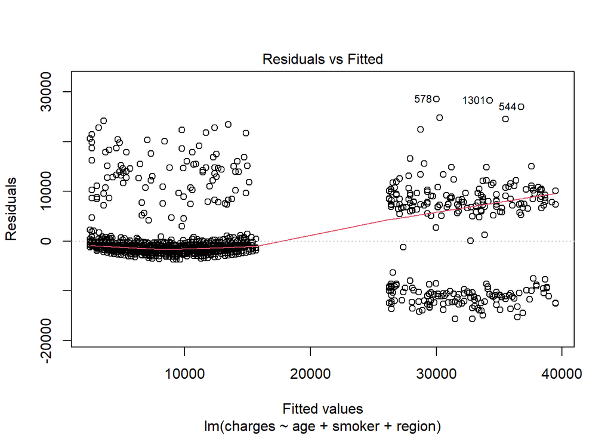

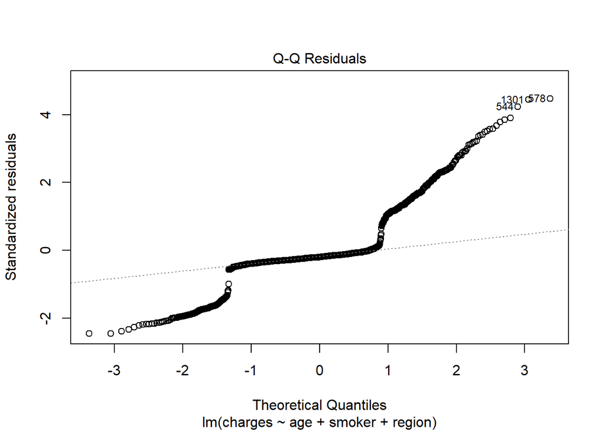

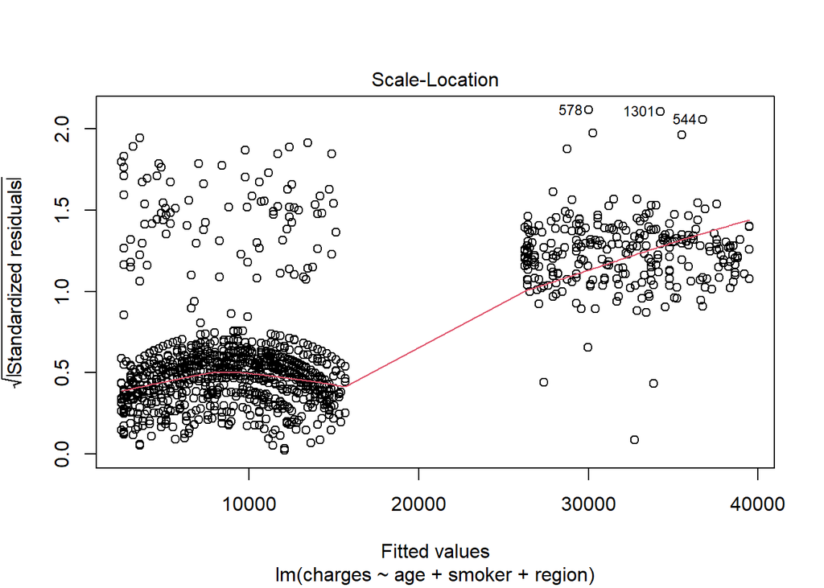

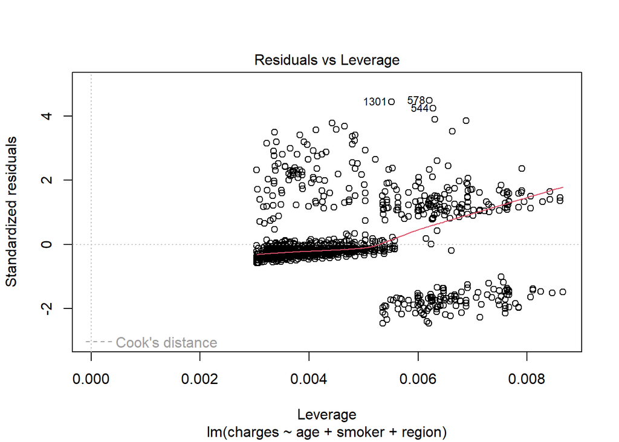

```r
plot(prelim.final.m)
```

# **check QQ plot**

```r
library(lmtest)
bptest(prelim.final.m)
```

```
##
##  studentized Breusch-Pagan test
##
## data:  prelim.final.m
## BP = 246.66, df = 5, p-value < 2.2e-16
```

```r
shapiro.test(prelim.final.m$residuals)
```

```
##
##  Shapiro-Wilk normality test
##
## data:  prelim.final.m$residuals
## W = 0.82111, p-value < 2.2e-16
```

# **Plot residuals against**

# **Age vs residual**

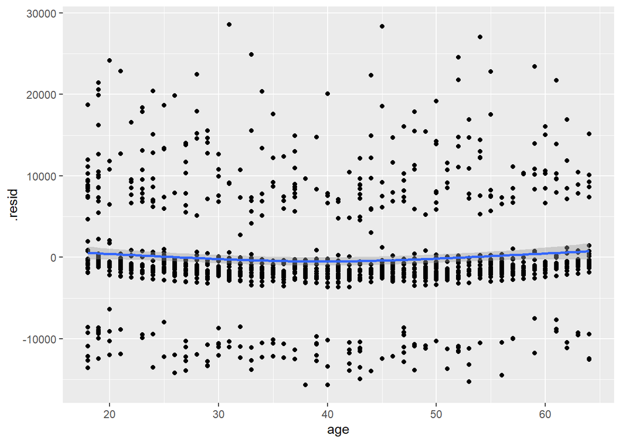

```r
augment(prelim.final.m) %>%
  ggplot(aes(x = age, y = .resid))+
  geom_point()+
  geom_smooth()
```

# **smoker vs residual**

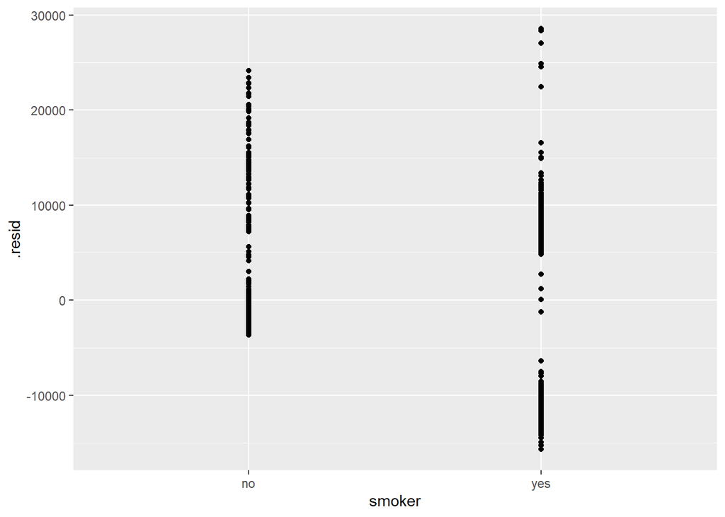

```r
augment(prelim.final.m) %>%
  ggplot(aes(x = smoker, y = .resid))+
  geom_point()+
  geom_smooth()
```

# **region vs residual**

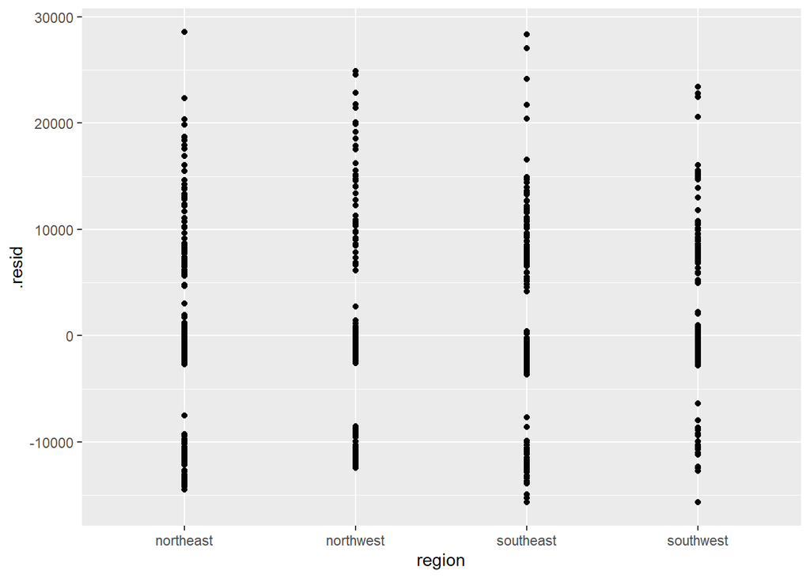

```r
augment(prelim.final.m) %>%
  ggplot(aes(x = region, y = .resid))+
  geom_point()+
  geom_smooth()
```

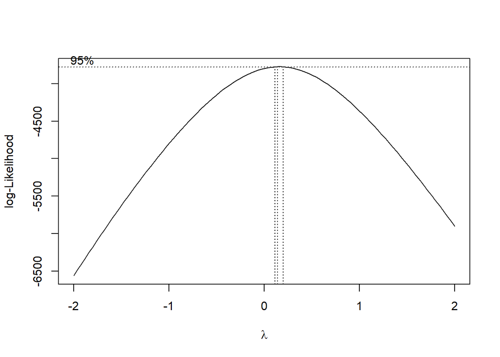

```r
MASS::boxcox(prelim.final.m)
```

# **plot to check model assessment**

Steps: Generate the fitted value Generate the residuals Generate the influential values Based on the values above,

make some plots to check assumptions generate some diagnostic values to assess the outliers and find influential observations

```r
res.mod <- residuals(prelim.final.m)
head(res.mod)
```

```
##         1         2         3         4         5         6
## -9384.999 -1300.003 -1327.130 15518.581 -2323.931 -2845.281
```

# **histogram**

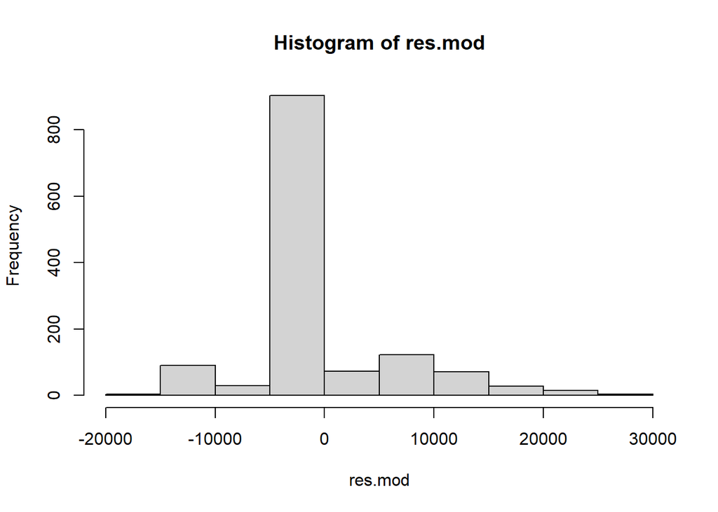

```r
hist(res.mod)
```

```r
library(DT)
```

# **Predictions**

```r
ourdata1.pred.res <- augment(prelim.final.m)
ourdata1.pred.res %>% datatable()
```

|  | charges | age | smoker | region | .fitted | .resid | .hat | .sigma | .cooksd | .std.resid |
| --- | --- | --- | --- | --- | --- | --- | --- | --- | --- | --- |
| 1 | 16884.924 | 19 | yes | southwest | 26269.92318047615 | -9384.999180476148 | 0.007672189182278142 | 6393.021307005962 | 0.002795966979067772 | -1.473023156186002 |
| 2 | 1725.5523 | 18 | no | southeast | 3025.555291148689 | -1300.002991148689 | 0.004732030706916546 | 6398.135021851652 | 3.289355291279808e-05 | -0.2037404468886747 |
| 3 | 4449.462 | 28 | no | southeast | 5776.591805087163 | -1327.129805087163 | 0.003507181192609473 | 6398.130945402033 | 2.534493870362455e-05 | -0.2078639772055458 |
| 4 | 21984.47061 | 33 | no | northwest | 6465.889565818498 | 15518.5810441815 | 0.003376694111334196 | 6384.031491055682 | 0.003335709660249627 | 2.430465192235617 |
| 5 | 3866.8552 | 32 | no | northwest | 6190.785914424651 | -2323.930714424651 | 0.003428626612417903 | 6397.916533651578 | 7.596338524475422e-05 | -0.363975279736454 |
| 6 | 3756.6216 | 31 | no | southeast | 6601.902759268706 | -2845.281159268706 | 0.003287608654988652 | 6397.75781797672 | 0.0001091554335447124 | -0.4455979414777376 |
| 7 | 8240.5896 | 46 | no | southeast | 10728.45753017642 | -2487.867930176417 | 0.003213546620762701 | 6397.870136037895 | 8.156232120126218e-05 | -0.3896091742844565 |
| 8 | 7281.5056 | 37 | no | northwest | 7566.304171393888 | -284.7985713938879 | 0.003244801192471862 | 6398.229941551512 | 1.079297744668258e-06 | -0.04460119226153141 |
| 9 | 6406.4107 | 37 | no | northeast | 7861.275394439271 | -1454.86469443927 | 0.003306398426826167 | 6398.110032719606 | 2.870328727280916e-05 | -0.2278477195814753 |
| 10 | 28923.13692 | 60 | no | northwest | 13893.68815345238 | 15029.44876654762 | 0.004841158412933172 | 6384.89402348175 | 0.004498887874935437 | 2.355590346766286 |

[output cut: 1328 more lines]

# **Check for Influential**

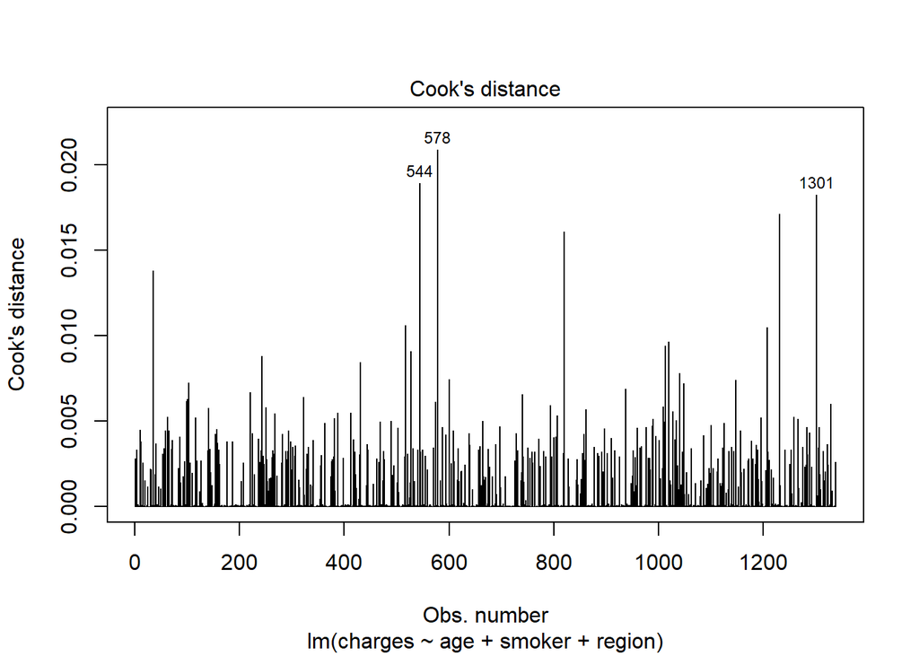

```r
cutoff <- 4/((nrow(ourdata1)-length(prelim.final.m$coefficients)-2))
plot(prelim.final.m, which = 4, cook.levels = cutoff)
```

```r
ourdata1.pred.res %>%
  filter(.std.resid > 2 | .std.resid < -2 ) %>%
  datatable()
```

|  | charges | age | smoker | region | .fitted | .resid | .hat | .sigma | .cooksd | .std.resid |
| --- | --- | --- | --- | --- | --- | --- | --- | --- | --- | --- |
| 1 | 21984.47061 | 33 | no | northwest | 6465.889565818498 | 15518.5810441815 | 0.003376694111334196 | 6384.031491055682 | 0.003335709660249627 | 2.430465192235617 |
| 2 | 28923.13692 | 60 | no | northwest | 13893.68815345238 | 15029.44876654762 | 0.004841158412933172 | 6384.89402348175 | 0.004498887874935437 | 2.355590346766286 |
| 3 | 51194.55914 | 28 | yes | southwest | 28745.85604302077 | 22448.70309697922 | 0.006630618352084155 | 6368.379659384271 | 0.01379652101250051 | 3.521589965747042 |
| 4 | 23244.7902 | 53 | yes | southeast | 36451.40953375742 | -13206.61933375742 | 0.006161903297332622 | 6387.922560704522 | 0.004433242622407231 | -2.071270196976743 |
| 5 | 30166.61817 | 64 | no | northwest | 14994.10275902777 | 15172.51541097223 | 0.005528306017173359 | 6384.62915590407 | 0.005242965261460554 | 2.378834841520777 |
| 6 | 22412.6485 | 56 | yes | northeast | 36885.47121474645 | -14472.82271474645 | 0.00713833385101995 | 6385.836180171561 | 0.006179885610738507 | -2.270972039749007 |
| 7 | 15820.699 | 38 | yes | southwest | 31496.89255695925 | -15676.19355695925 | 0.006193769741634591 | 6383.70005960307 | 0.006278956047168635 | -2.458627167329523 |
| 8 | 21344.8467 | 18 | no | northeast | 2634.30601795617 | 18710.54068204383 | 0.005027337784402588 | 6377.543021614153 | 0.007243409319682295 | 2.932808322186485 |
| 9 | 30259.99556 | 60 | no | northeast | 14188.65937649776 | 16071.33618350224 | 0.004886087274921719 | 6382.977300045999 | 0.005192472176875888 | 2.518943946282181 |
| 10 | 27322.73386 | 54 | no | southeast | 12929.2867413272 | 14393.4471186728 | 0.003871748055522123 | 6386.012187611409 | 0.003293523673530983 | 2.254810789400294 |

[output cut: 84 more lines]

```r
non.influen.obs <-
  ourdata1.pred.res %>%
  filter(.std.resid < 2 & .std.resid > -2)
```

```r
prelim.final.m2 <- lm(charges ~ age + smoker + region, data = non.influen.obs)
summary(prelim.final.m2)
```

```
##
## Call:
## lm(formula = charges ~ age + smoker + region, data = non.influen.obs)
##
## Residuals:
##      Min       1Q   Median       3Q      Max
## -13130.3  -1221.2   -280.8    670.2  13692.6
##
## Coefficients:
##                  Estimate Std. Error t value Pr(>|t|)
## (Intercept)     -3268.272    461.047  -7.089 2.27e-12 ***
## age               277.334      9.261  29.947  < 2e-16 ***
## smokeryes       24889.078    332.294  74.901  < 2e-16 ***
## regionnorthwest  -923.939    377.721  -2.446   0.0146 *
## regionsoutheast   599.215    367.922   1.629   0.1036
## regionsouthwest  -478.317    375.638  -1.273   0.2031
## ---
## Signif. codes:  0 '***' 0.001 '**' 0.01 '*' 0.05 '.' 0.1 ' ' 1
##
## Residual standard error: 4602 on 1238 degrees of freedom
## Multiple R-squared:  0.8394, Adjusted R-squared:  0.8388
## F-statistic:  1295 on 5 and 1238 DF,  p-value: < 2.2e-16
```

R square improve from previous preliminary model after removing the influential by ~11%

```r
tidy(prelim.final.m2, conf.int = TRUE)
```

```
## # A tibble: 6 × 7
##   term            estimate std.error statistic   p.value conf.low conf.high
##   <chr>              <dbl>     <dbl>     <dbl>     <dbl>    <dbl>     <dbl>
## 1 (Intercept)       -3268.    461.       -7.09 2.27e- 12   -4173.    -2364.
## 2 age                 277.      9.26     29.9  1.15e-148     259.      296.
## 3 smokeryes         24889.    332.       74.9  0           24237.    25541.
## 4 regionnorthwest    -924.    378.       -2.45 1.46e-  2   -1665.     -183.
## 5 regionsoutheast     599.    368.        1.63 1.04e-  1    -123.     1321.
## 6 regionsouthwest    -478.    376.       -1.27 2.03e-  1   -1215.      259.
```

# **Rerun Diagnostic plots for preliminary final model 2**

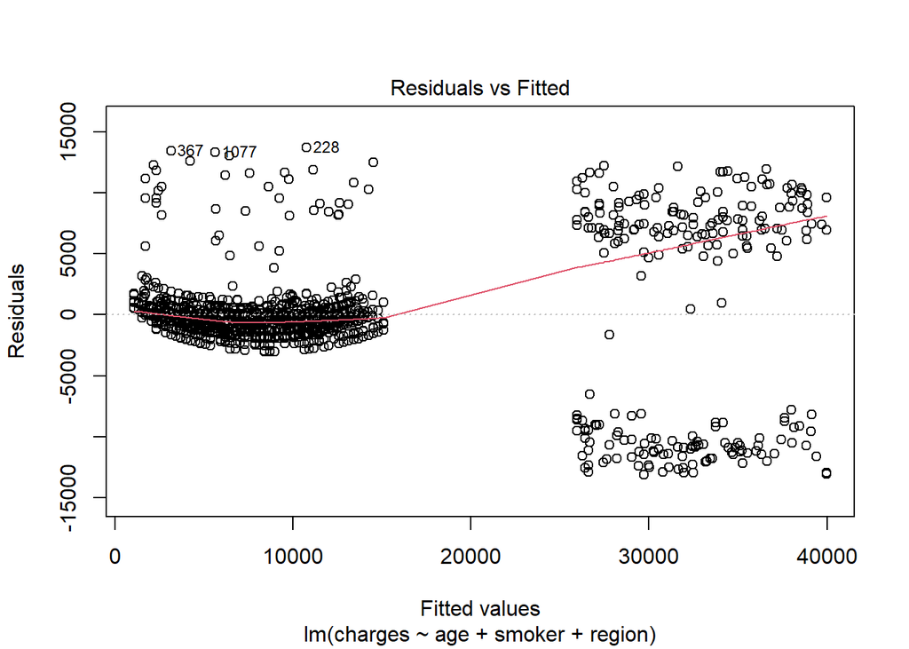

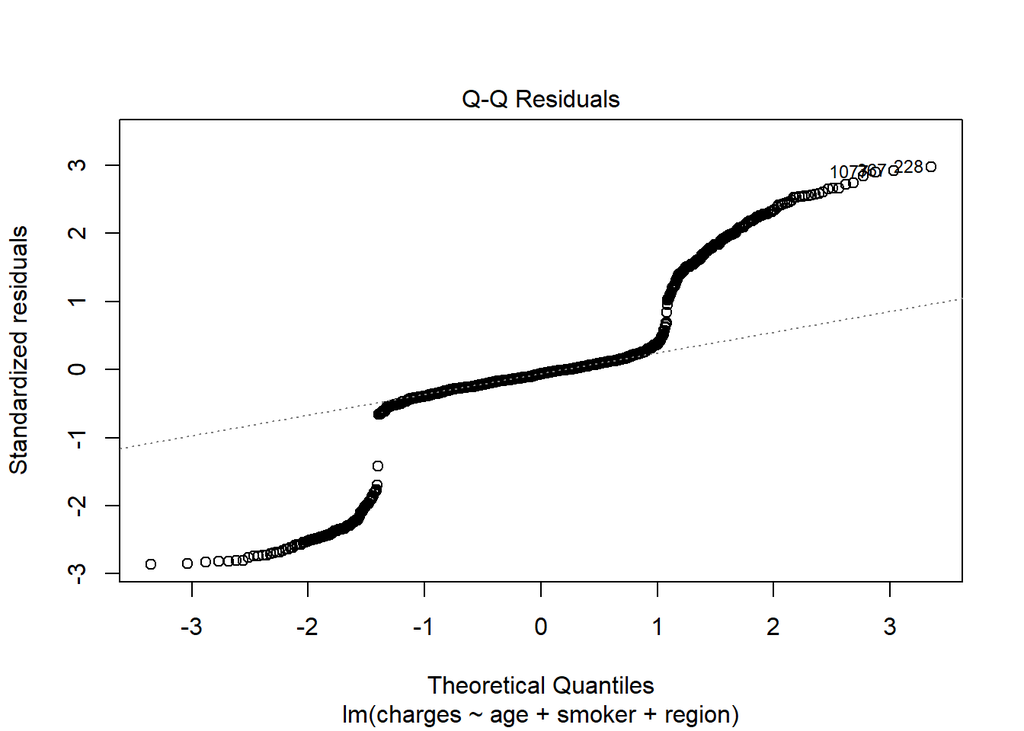

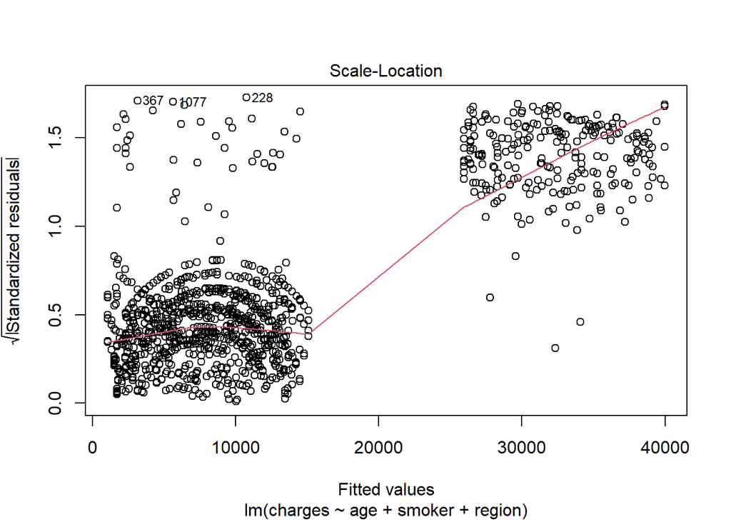

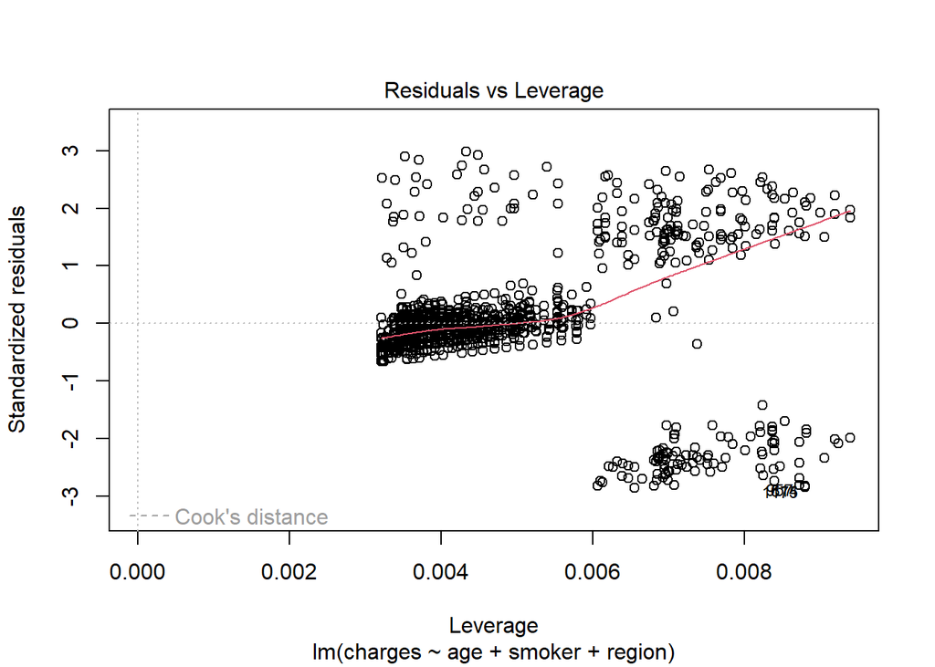

```r
plot(prelim.final.m2)
```

```r
bptest(prelim.final.m2)
```

```
##
##  studentized Breusch-Pagan test
##
## data:  prelim.final.m2
## BP = 763.62, df = 5, p-value < 2.2e-16
```

```r
shapiro.test(prelim.final.m2$residuals)
```

```
##
##  Shapiro-Wilk normality test
##
## data:  prelim.final.m2$residuals
## W = 0.83824, p-value < 2.2e-16
```

# **Final Model**

```r
summary(prelim.final.m2)
```

```
##
## Call:
## lm(formula = charges ~ age + smoker + region, data = non.influen.obs)
##
## Residuals:
##      Min       1Q   Median       3Q      Max
## -13130.3  -1221.2   -280.8    670.2  13692.6
##
## Coefficients:
##                  Estimate Std. Error t value Pr(>|t|)
## (Intercept)     -3268.272    461.047  -7.089 2.27e-12 ***
## age               277.334      9.261  29.947  < 2e-16 ***
## smokeryes       24889.078    332.294  74.901  < 2e-16 ***
## regionnorthwest  -923.939    377.721  -2.446   0.0146 *
## regionsoutheast   599.215    367.922   1.629   0.1036
## regionsouthwest  -478.317    375.638  -1.273   0.2031
## ---
## Signif. codes:  0 '***' 0.001 '**' 0.01 '*' 0.05 '.' 0.1 ' ' 1
##
## Residual standard error: 4602 on 1238 degrees of freedom
## Multiple R-squared:  0.8394, Adjusted R-squared:  0.8388
## F-statistic:  1295 on 5 and 1238 DF,  p-value: < 2.2e-16
```

```r
tidy(prelim.final.m2)
```

```
## # A tibble: 6 × 5
##   term            estimate std.error statistic   p.value
##   <chr>              <dbl>     <dbl>     <dbl>     <dbl>
## 1 (Intercept)       -3268.    461.       -7.09 2.27e- 12
## 2 age                 277.      9.26     29.9  1.15e-148
## 3 smokeryes         24889.    332.       74.9  0
## 4 regionnorthwest    -924.    378.       -2.45 1.46e-  2
## 5 regionsoutheast     599.    368.        1.63 1.04e-  1
## 6 regionsouthwest    -478.    376.       -1.27 2.03e-  1
```

```r
FinalModelMLR <- tbl_regression(prelim.final.m2) %>%  add_glance_table(include = c(adj.r.squared)) %>%
  bold_labels() %>% italicize_levels() %>%
  as_gt() %>%
  gt::tab_header(title = "Table 3. Multiple Linear Regression (Final Model)")
FinalModelMLR
```

Table 3. Multiple Linear Regression (Final Model)

| **Characteristic** | **Beta** | **95% CI**<sup>1</sup> | **p-value** |
| --- | --- | --- | --- |
| age | 277 | 259, 296 | <0.001 |
| smoker |  |  |  |
| no | — | — |  |
| yes | 24,889 | 24,237, 25,541 | <0.001 |
| region |  |  |  |
| northeast | — | — |  |
| northwest | -924 | -1,665, -183 | 0.015 |
| southeast | 599 | -123, 1,321 | 0.10 |
| southwest | -478 | -1,215, 259 | 0.2 |
| Adjusted R² | 0.839 |  |  |

<sup>1</sup> CI = Confidence Interval

# **Model Equation**

Charges($)= -3268.27 + 277.33(age) + 24889.07(smoker) + -923.93(northwest) + 599.21(southeast) + -478.31(southwest)

#Interpretation

[output not shown]